# Attention and performance

KINESIOL 2MC3

Mike Carter, Ph.D.

cartem11@email.com

Department of Kinesiology | McMaster University

September 16 2025

## Last class

## Lecture objectives

- Describe stimulus-response compatibility and how it affects reaction time
- Explain the spatial and anatomical accounts for stimulus-response compatibility effects
- Discuss how an irrelevant stimulus feature can influence reaction time
- Understand the role of anticipation in minimizing processing delays

TAKE-HOME MESSAGE:  
Although reaction time is one of the simplest performance measures, its use has had a profound influence on the development of motor behaviour research.

## Lecture objectives

- Understand properties of attention
- Explain how researchers can assess the attentional demands of a motor skill
- Describe how attention can limit information-processing activities
- Explain how attention influences the capability to perform actions

TAKE-HOME MESSAGE:  
Many factors influence how attention and arousal impact skilled motor performance.

## What is attention?

> Everyone knows what **attention** is. It is the taking possession by the mind, in clear and vivid form, of one out of what seem several simultaneously possible objects or trains of thought. Focalization, concentration of consciousness, is of its essence. It implies withdrawal from some things in order to deal effectively with others.  
> - *James (1890)*

[figure not shown]

## What is attention?

- **limited capacity** to engage in **multiple** cognitive and/or motor activities **simultaneously**
- **selective** attention to specific **environmental features** when we perform motor skills
  - this can happen either through **intentional** or **incidental** processes

[figure not shown]

## Activity

## What is attention?

- in **multi-task** situations, performance can suffer for two broad reasons:
  1. **structural interference** occurs when physical or neurological structures are the cause of the reduced performance (e.g., eyes, limbs, etc)
  2. **capacity interference** occurs when required attentional resources exceeds some attentional limit
- examples
  - distracted driving, inattention blindness, change blindness

## We can leverage interference as an indirect measure of attention

- two common secondary task methods are used by researchers
  - **DUAL-TASK METHOD:** the secondary task is performed for the duration of the primary task
    - e.g., walking and performing an *n*-back task
  - **PROBE-TASK METHOD:** the secondary task is required at some unexpected point while the person performs the primary task
    - e.g., respond to an *auditory beep* as quickly as possible with a manual or vocal response

## Attentional demands during an action

**Primary task:** Reach to a small or large target

**Secondary task:** Probe reaction time task to an auditory tone with a manual button response as rapidly as possible

- Auditory probe could be presented at **6 possible positions** in the movement: 0, 15, 45, 75, 105, or 135 degrees
- Position was randomized

[figure not shown]

Approximate data based on Posner and Keele (1969) through plot digitization of Schmidt and Lee (2011).

## Activity

## The time between the presentation of two stimuli can have a strong influence on performance

[video not shown]

Link: https://www.youtube.com/watch?v=rj0GLq3Q64M

[video not shown]

Link: https://www.youtube.com/watch?v=ZaaK36mX_Pk

## The psychological refractory period (PRP)

[figure not shown]

- Perform task 1 alone; perform task 2 alone
- Perform task 1 then task 2 sequentially but **manipulate the time between** the auditory and visual cues

## The psychological refractory period (PRP)

[figure not shown]

Approximate data based on Davis (1959) through plot digitization of Schmidt and Lee (2011)

- **PSYCHOLOGICAL REFRACTORY PERIOD:** The delay in responding to the second of two closely spaced stimuli

## The psychological refractory period (PRP)

[figure not shown]

Adapted from Maslovat et al. (2013)

- provides evidence of a **response preparation** bottleneck

## Focus of attention

- refers to the information that a performer’s attention (or consciousness) is directed at **before** or **during** an action
- **INTERNAL FOCUS OF ATTENTION:** focus on information associated with the performer’s **body**
  - e.g., “*Think about the timing of your hip rotation*”
- **EXTERNAL FOCUS OF ATTENTION:** focus on information that is **external** to the performer’s body
  - e.g., “*Think about the tennis racquet hitting the ball*”

it is *NOT* a visual focus…it is a *MENTAL FOCUS*

The evidential value of the attentional focus literature has been questioned (McKay et al. 2024), which we will revisit in the motor learning metascience lecture

## Focus of attention

**Task:** Stabilometer

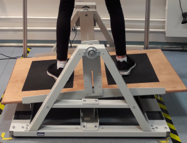

**Groups:**

- internal = feet
- external = markers on platform
- control = no instructions

[figure not shown]

Approximate data based on Wulf et al. (2003) through plot digitization

## Focus of attention

**Task:** Golf pitch shot

[figure not shown]

**Groups:**

- internal focus = arm swing
- external focus = club swing

[figure not shown]

Approximate data based on Wulf et al. (1999) through plot digitization

## Attentional focus - Explanations

- **CONSTRAINED ACTION HYPOTHESIS:** an internal focus produces conscious, moment-to-moment movement control that constrains the sensorimotor system and interferes with automatic control processes whereas an external focus allows the sensorimotor system to more naturally self-organize (McNevin et al. 2003; Wulf et al. 2001)

## Attentional focus - Explanations

**Task:** Stabilometer

**Secondary task:** Simple RT button press

- randomly 8x in a trial

**Groups:**

- internal = feet
- external = markers on platform

[figure not shown]

Approximate data from Wulf et al. (2001) through plot digitization

## Attentional focus - Explanations

**Task:** Basketball free throw

**Groups:**

**EMG:** Flexor carpi radialis (FCR), Biceps brachii (BB), Triceps brachii (TB), and Deltoid (D)

[figure not shown]

Approximate data from Zachry et al. (2005) through plot digitization

## Attentional focus - Explanations

- **CONSTRAINED ACTION HYPOTHESIS:** an internal focus produces conscious, moment-to-moment movement control that constrains the sensorimotor system and interferes with automatic control processes whereas an external focus allows the sensorimotor system to more naturally self-organize (McNevin et al. 2003; Wulf et al. 2001)
- **TASK-RELEVANT INFORMATION ATTUNEMENT:** attentional focus enhances performance by prioritizing task-relevant information that is most critical for achieving a task goal whether external or internal (Herrebrøden 2023)

## Decision-making under stress

- **AROUSAL:** the level of excitement produced under stress
- one’s **level of arousal** is an **important determinant of performance** in tasks where the **speed and/or accuracy of motor decisions** is important
- **INVERTED-U PRINCIPLE:** The relationship between arousal level and performance
- Why do some people succeed under pressure and others *“choke”* (Beilock 2011)?

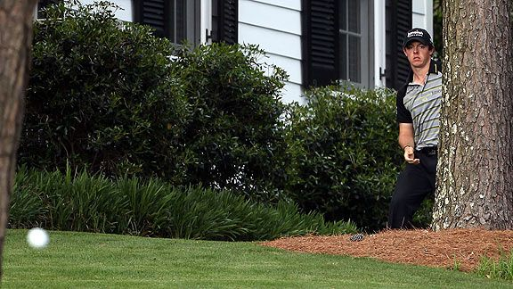

## Lecture objectives

- Understand properties of attention
- Explain how researchers can assess the attentional demands of a motor skill
- Describe how attention can limit information-processing activities
- Explain how attention influences the capability to perform actions

TAKE-HOME MESSAGE:  
Many factors influence how attention and arousal impact skilled motor performance.

## What questions do you have?

[figure not shown]

*Next class: Sensory contributions I*

## References

**Beilock S**. *Choke: What the secrets of the brain reveal about getting it right when you have to*. New York, NY: Atria Books, 2011.

**Davis R**. The role of "attention" in the psychological refractory period. *Quarterly Journal of Experimental Psychology* 11: 211–220, 1959.

**Herrebrøden H**. Motor performers need task-relevant information: Proposing an alternative mechanism for the attentional focus effect. *Journal of Motor Behavior* 55: 125–134, 2023.

**James W**. *The principles of psychology (volume i)*. New York, NY: Henry Holt; Company, 1890.

**Maslovat D**, **Chua R**, **Spencer HC**, **Forgaard CJ**, **Carlsen AN**, **Franks IM**. Evidence for a response preparation bottleneck during dual-task performance: Effect of a startling acoustic stimulus on the psychological refractory period. *Acta Psychologica* 144: 481–487, 2013.

**McKay B**, **Corson AE**, **Seedu J**, **De Faveri CS**, **Hasan H**, **Arnold K**, **Adams FC**, **Carter MJ**. Reporting bias, not external focus: A robust bayesian meta-analysis and systematic review of the external focus of attention literature. *Psychological Bulletin* 150: 1347, 2024.

**McNevin NH**, **Shea CH**, **Wulf G**. Increasing the distance of an external focus of attention enhances learning. *Psychological Eesearch* 67: 22–29, 2003.

**Posner MI**, **Keele SW**. Attentional demands of movement. In: *Proceedings of the 16th congress of applied psychology*. Swets; Zeitlinger, 1969, p. 418–422.

**Schmidt RA**, **Lee TD**. *Motor control and learning: A behavioral emphasis*. Human Kinetics, 2011.

**Wulf G**, **Lauterbach B**, **Toole T**. The learning advantages of an external focus of attention in golf. *Research Quarterly for Exercise and Sport* 70: 120–126, 1999.

**Wulf G**, **McNevin N**, **Shea CH**. The automaticity of complex motor skill learning as a function of attentional focus. *The Quarterly Journal of Experimental Psychology Section A* 54: 1143–1154, 2001.

**Wulf G**, **Weigelt M**, **Poulter D**, **McNevin N**. Attentional focus on suprapostural tasks affects balance learning. *The Quarterly Journal of Experimental Psychology Section A* 56: 1191–1211, 2003.

**Zachry T**, **Wulf G**, **Mercer J**, **Bezodis N**. Increased movement accuracy and reduced EMG activity as the result of adopting an external focus of attention. *Brain Research Bulletin* 67: 304–309, 2005.